# Personal Loan Campaign

```python
# Installing the libraries with the specified version.
!pip install numpy==1.25.2 pandas==1.5.3 matplotlib==3.7.1 seaborn==0.13.1 scikit-learn==1.2.2 sklearn-pandas==2.2.0 -q --user
```

```python
import numpy as np
import pandas as pd

import matplotlib.pyplot as plt
import seaborn as sns

from sklearn.model_selection import train_test_split
from sklearn.tree import DecisionTreeClassifier
from sklearn.tree import plot_tree
from sklearn.metrics import f1_score, accuracy_score, precision_score, recall_score, accuracy_score, silhouette_score
from sklearn.cluster import KMeans
from sklearn.preprocessing import LabelEncoder
```

**Loading the dataset**

```python
from google.colab import drive
drive.mount('/content/drive')
```

```python
file_path = '/content/drive/My Drive/Colab Notebooks/Loan_Modelling.csv'
df = pd.read_csv(file_path)
```

# **Data overview**

```python
# Check first 5 rows
print(df.head())
```

```
   ID  Age  Experience  Income  ZIPCode  Family  CCAvg  Education  Mortgage  \
0   1   25           1      49    91107       4    1.6          1         0
1   2   45          19      34    90089       3    1.5          1         0
2   3   39          15      11    94720       1    1.0          1         0
3   4   35           9     100    94112       1    2.7          2         0
4   5   35           8      45    91330       4    1.0          2         0

   Personal_Loan  Securities_Account  CD_Account  Online  CreditCard
0              0                   1           0       0           0
1              0                   1           0       0           0
2              0                   0           0       0           0
3              0                   0           0       0           0
4              0                   0           0       0           1
```

```python
# Check statistical info
df.describe()
```

|  | ID | Age | Experience | Income | ZIPCode | Family | CCAvg | Education | Mortgage | Personal_Loan | Securities_Account | CD_Account | Online | CreditCard |
| --- | --- | --- | --- | --- | --- | --- | --- | --- | --- | --- | --- | --- | --- | --- |
| count | 5000.000000 | 5000.000000 | 5000.000000 | 5000.000000 | 5000.000000 | 5000.000000 | 5000.000000 | 5000.000000 | 5000.000000 | 5000.000000 | 5000.000000 | 5000.00000 | 5000.000000 | 5000.000000 |
| mean | 2500.500000 | 45.338400 | 20.104600 | 73.774200 | 93169.257000 | 2.396400 | 1.937938 | 1.881000 | 56.498800 | 0.096000 | 0.104400 | 0.06040 | 0.596800 | 0.294000 |
| std | 1443.520003 | 11.463166 | 11.467954 | 46.033729 | 1759.455086 | 1.147663 | 1.747659 | 0.839869 | 101.713802 | 0.294621 | 0.305809 | 0.23825 | 0.490589 | 0.455637 |
| min | 1.000000 | 23.000000 | -3.000000 | 8.000000 | 90005.000000 | 1.000000 | 0.000000 | 1.000000 | 0.000000 | 0.000000 | 0.000000 | 0.00000 | 0.000000 | 0.000000 |
| 25% | 1250.750000 | 35.000000 | 10.000000 | 39.000000 | 91911.000000 | 1.000000 | 0.700000 | 1.000000 | 0.000000 | 0.000000 | 0.000000 | 0.00000 | 0.000000 | 0.000000 |
| 50% | 2500.500000 | 45.000000 | 20.000000 | 64.000000 | 93437.000000 | 2.000000 | 1.500000 | 2.000000 | 0.000000 | 0.000000 | 0.000000 | 0.00000 | 1.000000 | 0.000000 |
| 75% | 3750.250000 | 55.000000 | 30.000000 | 98.000000 | 94608.000000 | 3.000000 | 2.500000 | 3.000000 | 101.000000 | 0.000000 | 0.000000 | 0.00000 | 1.000000 | 1.000000 |
| max | 5000.000000 | 67.000000 | 43.000000 | 224.000000 | 96651.000000 | 4.000000 | 10.000000 | 3.000000 | 635.000000 | 1.000000 | 1.000000 | 1.00000 | 1.000000 | 1.000000 |

Age: With a mean of 45.3 and a median of 45.0 the age distribution among customers is symmetrical.

Experience: The presence of a minimum value of -3 suggests a data quality issue requiring correction.

Income: This has a right-skewed distribution, as evidenced by the mean (73.77) being higher than the median (64.0) and a considerable difference between the 75th percentile (98.0) and the maximum (224.0). There are more lower income customers than high income.

CCAvg: Also has a right-skewed distribution, with a mean (1.93) larger than the median (1.50) and a large difference between the 75th percentile (2.50) and the maximum (10.00). Most customers spend low amounts on average on credit cards and a small group spends more.

Mortgage: The minimum, 25th percentile and median values are all 0, which means that at least half of the customers don't have a mortgage. The distribution is highly right-skewed, having a lot of 0s (no mortgage) and a long tail to higher mortgage values for those who do have a mortgage.

```python
# Check how many rows and columns
df.shape
```

```
(5000, 14)
```

```python
# Check data types and obvious missing values
print(df.info())
```

```
<class 'pandas.core.frame.DataFrame'>
RangeIndex: 5000 entries, 0 to 4999
Data columns (total 14 columns):
 #   Column              Non-Null Count  Dtype
---  ------              --------------  -----
 0   ID                  5000 non-null   int64
 1   Age                 5000 non-null   int64
 2   Experience          5000 non-null   int64
 3   Income              5000 non-null   int64
 4   ZIPCode             5000 non-null   int64
 5   Family              5000 non-null   int64
 6   CCAvg               5000 non-null   float64
 7   Education           5000 non-null   int64
 8   Mortgage            5000 non-null   int64
 9   Personal_Loan       5000 non-null   int64
 10  Securities_Account  5000 non-null   int64
 11  CD_Account          5000 non-null   int64
 12  Online              5000 non-null   int64
 13  CreditCard          5000 non-null   int64
dtypes: float64(1), int64(13)
memory usage: 547.0 KB
None
```

```python
# Look for missing values in the data even though info() already indicates that there are no NaN
# print(df.isnull().sum())
# print(df.isnull().mean() * 100)
# print(df[df.isnull().any(axis=1)])
# print(df.isnull().sum().sum())
```

**Conclusion:** There are no null values in the dataset.

# **Exploratory Data Analysis - Univariate**

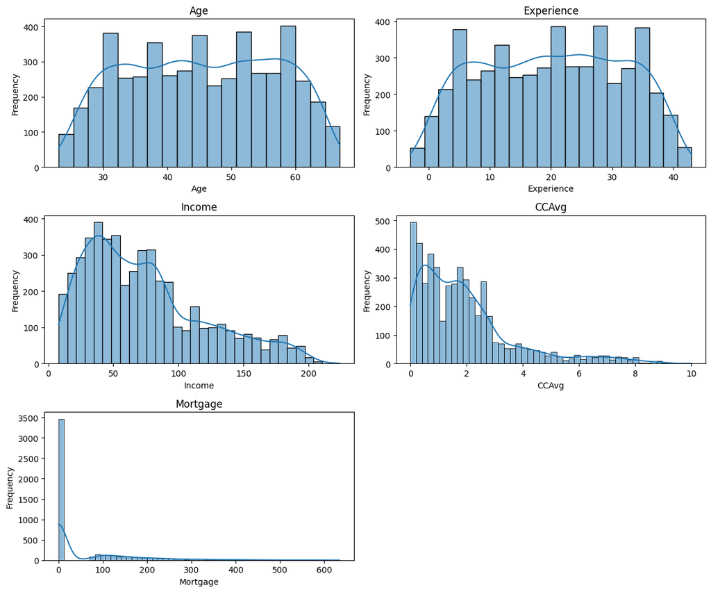

```python
# Select numerical columns for plotting (except ID)
numerical_cols = ['Age', 'Experience', 'Income', 'CCAvg', 'Mortgage']

plt.figure(figsize=(12, 10))

for i, col in enumerate(numerical_cols):
    plt.subplot(3, 2, i + 1)
    sns.histplot(df[col], kde=True)
    plt.title(f'{col}')
    plt.xlabel(col)
    plt.ylabel('Frequency')

plt.tight_layout()
plt.show()
```

**Conclusions:**

Both 'Age' and 'Experience' appear to have distributions that are almost uniform. The bars for 'Age' are relatively even between 30 and 60, and for 'Experience' between 10 and 30.

'Mortgage's distribution is highly right-skewed. There is a peak at 0, indicating that many customers don't have a mortgage. The tail represents a smaller number of customers with large mortgage amounts.

'CCAvg's distribution is also highly right-skewed. It suggests that a large concentration of customers spend very little, while a long tail represents a smaller number of individuals who spend more.

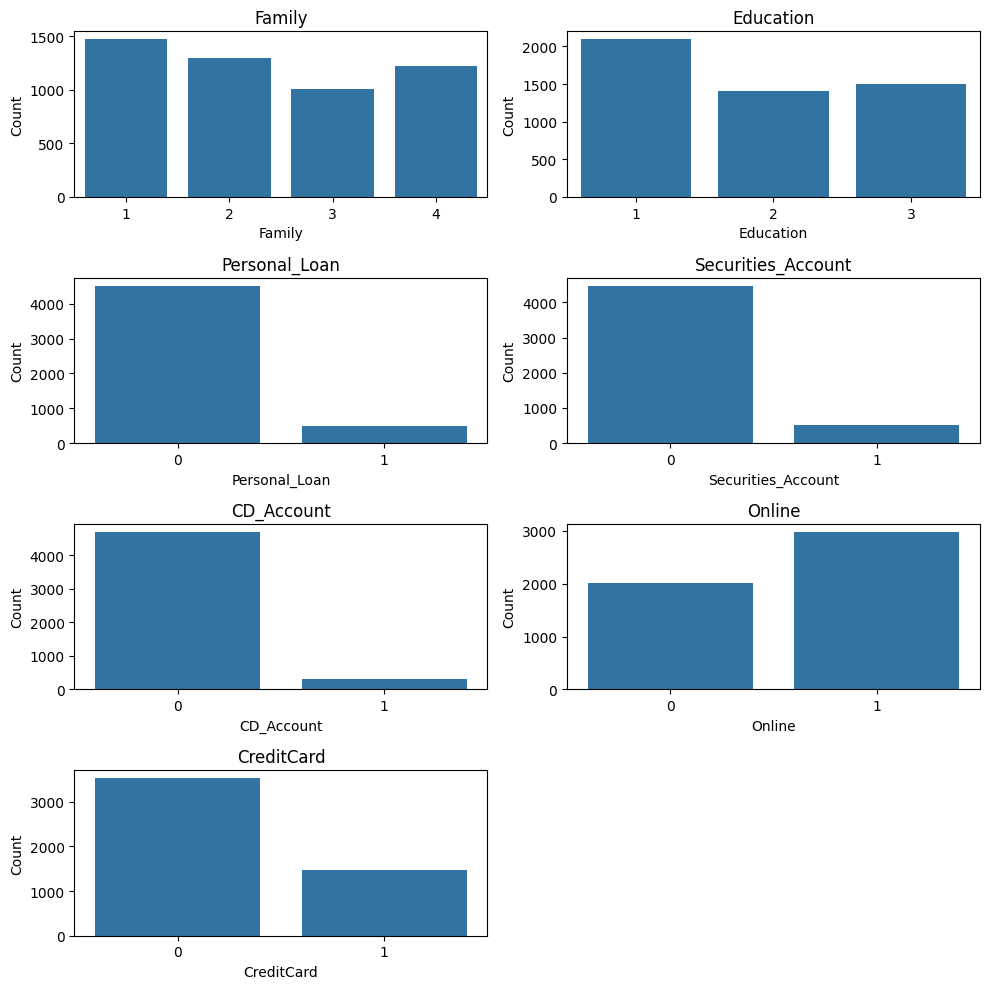

```python
# Select discrete columns
discrete_cols = ['Family', 'Education', 'Personal_Loan', 'Securities_Account', 'CD_Account', 'Online', 'CreditCard']

plt.figure(figsize=(10, 10))

for i, col in enumerate(discrete_cols):
    plt.subplot(4, 2, i + 1)
    sns.countplot(x=df[col])
    plt.title(f'{col}')
    plt.xlabel(col)
    plt.ylabel('Count')
plt.tight_layout()
plt.show()
```

**Conclusions:**

'Family' indicates that most families have 1 or 2 members. However, the family members numbers doesn't diverge a lot.

'Education' shows that most education level is 'Undergrad', followed by 'Advances/Professional'.

'Securities_Account' reflects that the majority of the customers don't have a securities account with the bank, similarly to 'CD_Account'.

'Online' indicates that most of the customers use internet banking services.

Looking at 'CreditCard', it is clear that the majority of customers in the dataset do not have a credit card.

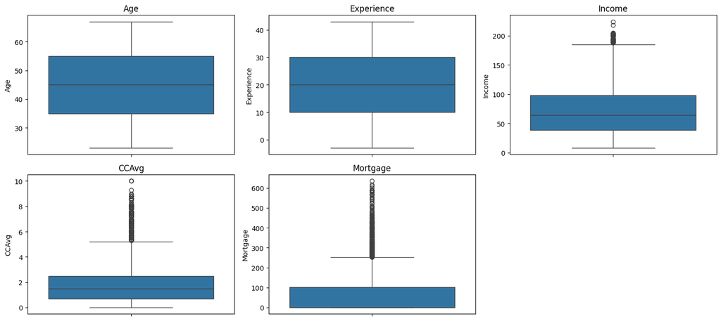

```python
# Verify outliers

plt.figure(figsize=(15, 10))
for i, col in enumerate(numerical_cols):
    plt.subplot(3, 3, i + 1)
    sns.boxplot(y=df[col])
    plt.title(f'{col}')
    plt.ylabel(col)
plt.tight_layout()
plt.show()
```

**Conclusion:**

'Age': The median age is around 45 years old and there are no outliers.

'Experience': The median experience is 20 years and also no outliers.

'Income': The median income is around 60. The IQR is small indicating that 50% of the income values are clustered in that range. There are several outliers.

'CCAvg': The median is around 1.5, which is relatively low, meaning that on average customers don't spend a lot on their credit cards. As verified by the IQR, most customers spend very little. There are plenty of outliers, indicating that there is a small number of customers who spend high amounts on their credit cards average.

**Q1. What is the distribution of the mortgage attribute? Are there any noticeable patterns or outliers in the distribution?**

The distribution of 'Mortgage' is highly right skewed.

Many customers have 0 mortgages and there is also a reasonable amount of outliers (customers with high mortgage values).

**Q2. How many customers have credit cards?**

The 'CreditCard' column has a mean of 0.294, which represents the proportion of customers who have a credit card. There are 5000 customers in total Therefore, the number of customers with credit cards is 0.294 x 5000 = 1470

Approximately 1470 customers in the dataset have credit cards.

# **Exploratory Data Analysis - Multivariate**

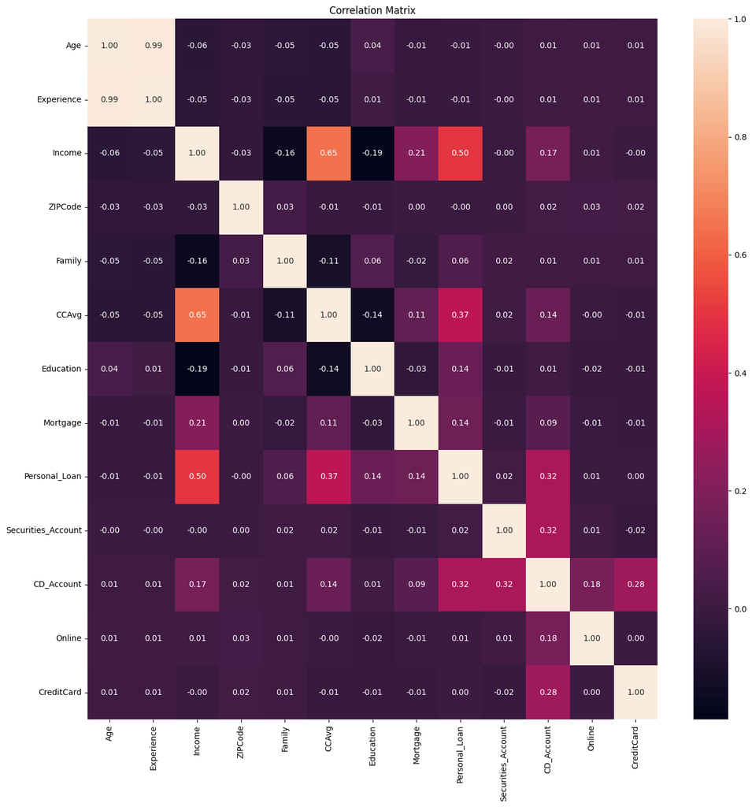

```python
num_cols_corr = ['Age', 'Experience', 'Income', 'ZIPCode', 'Family', 'CCAvg', 'Education', 'Mortgage', 'Personal_Loan', 'Securities_Account', 'CD_Account', 'Online', 'CreditCard']

correlation_matrix = df[num_cols_corr].corr()

plt.figure(figsize=(14, 14))
sns.heatmap(correlation_matrix, annot=True, fmt=".2f")
plt.title('Correlation Matrix')
plt.tight_layout()
plt.show()
```

**Q3. What are the attributes that have a strong correlation with the target attribute (personal loan)?**

The attributes that have a strong correlation with the target attribute 'Personal_Loan' are:

'Income': [0.50] This is the strongest correlation that indicates that if a customer's income increases, they're more likely to accept a personal loan.

'CCAvg': [0.37] This correlation suggests that customers that spend more on average on their credit cards, are more likely to take on a personal loan.

'CD_Account': [0.32] This correlation demonstrates that customers who own a Certificate of Deposit account are more likely to take on a personal loan.

**Q4. How does a customer's interest in purchasing a loan vary with their age?**

The correlation coefficient between 'Age' and 'Personal_Loan' is -0.01, which is extremely low. Therefore, there doesn't seem to be a correlation between the age of the customers and the likelihood of them taking on a loan or not.

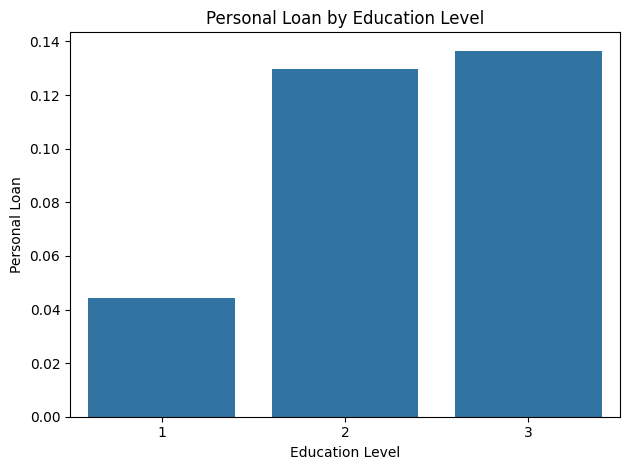

```python
sns.barplot(x='Education', y='Personal_Loan', data=df, errorbar=None)
plt.title('Personal Loan by Education Level')
plt.xlabel('Education Level')
plt.ylabel('Personal Loan')
plt.tight_layout()
plt.show()
```

**Q5. How does a customer's interest in purchasing a loan vary with their education?**

Even though the correlation coefficient (only 0.14) suggests a weak correlation, the barplot shows that customers with 'Graduate' or 'Advanced/Professional' education levels are more likely to accept personal loans compared to 'Undergrad'. It is possible that customers with higher levels of education take more personal loans due to higher income.

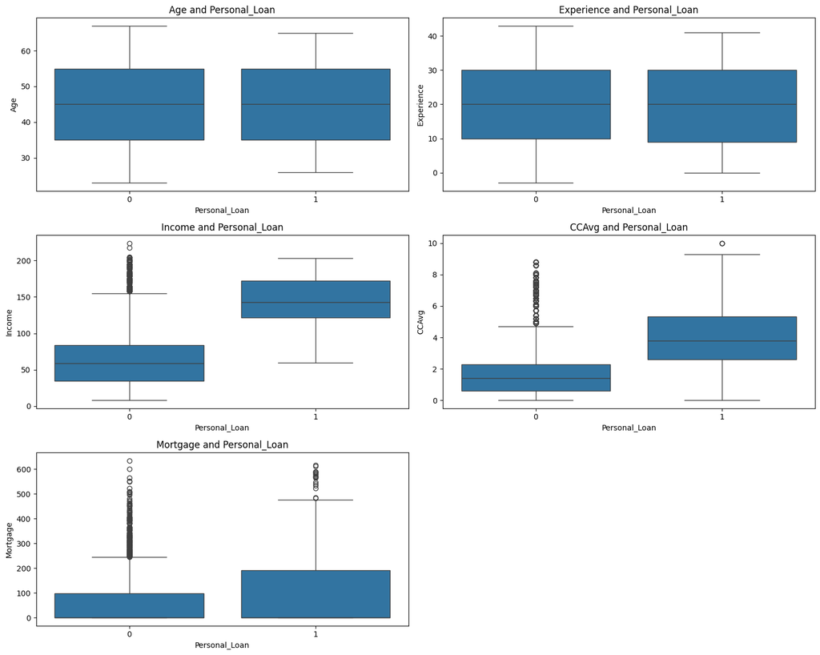

```python
# Numerical Features and Personal_Loan
numerical_cols = ['Age', 'Experience', 'Income', 'CCAvg', 'Mortgage']

plt.figure(figsize=(15, 12))

for i, col in enumerate(numerical_cols):
    plt.subplot(3, 2, i+1)
    sns.boxplot(x='Personal_Loan', y=col, data=df)
    plt.title(f'{col} and Personal_Loan')
    plt.xlabel('Personal_Loan')
    plt.ylabel(col)

plt.tight_layout()
plt.show()
```

'Age': The median age is 45 years. The IQR ranges from 35 to 55 years, indicating that 50% of the customers fall within this age bracket. There are no outliers. Both distributions (with personal loan and without) are very similar, suggesting that 'Age' is not a strong factor.

'Experience': The median is around 20 years. The IQR ranges from about 10 to 30 years. No outliers. Again, very similar distributions, thus weak correlation between 'Experience' and 'Personal_Loan'.

'Income': The median income is around 60 for the customers without a personal loan and around 140 for the customers with a personal loan. Customers with a personal loan have a higher median income as well as a higher distribution. Looking back at the correlation matrix, 'Income' was the highest correlation [0.50].

'CCAvg': Customers with a personal loan have a higher average on credit card spendings. For non-loan customers, the median is around 1.0-1.5, while for loan customers the median is higher, around 3.0-4.0. Their correlation coefficient is [0.37] which is already significant.

As a result, it seems that 'Income' and 'CCAvg' are good indicators of being able to take or not a personal loan: when they increase, the customers are more likely to take on a personal loan.

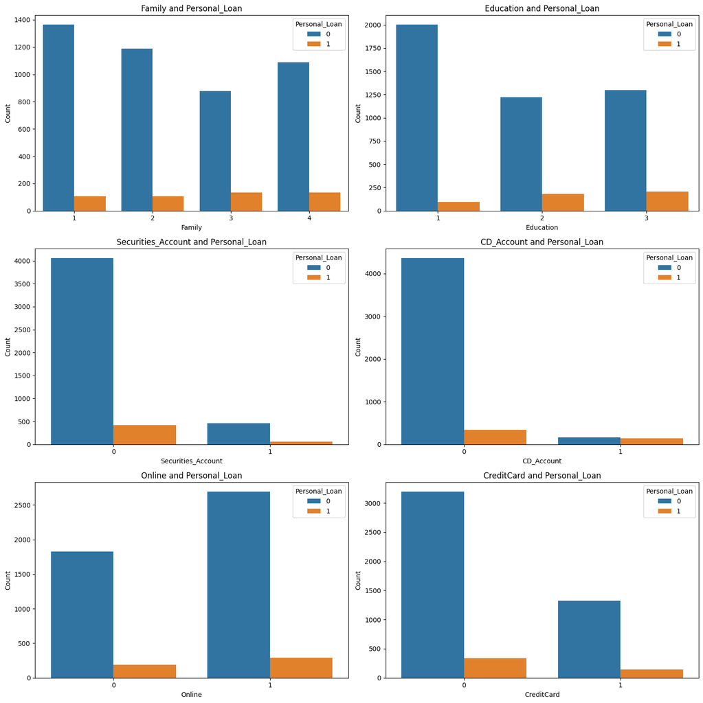

```python
# Categorical features and Personal_Loan
categorical_cols = ['Family', 'Education', 'Securities_Account', 'CD_Account', 'Online', 'CreditCard']

plt.figure(figsize=(15, 15))

for i, col in enumerate(categorical_cols, 1):
    plt.subplot(3, 2, i)
    sns.countplot(x=col, hue='Personal_Loan', data=df)
    plt.title(f'{col} and Personal_Loan')
    plt.xlabel(col)
    plt.ylabel('Count')
    plt.legend(title='Personal_Loan')

plt.tight_layout()
plt.show()
```

Family' and 'Personal_Loan': Most customers do not take a personal loan. There is, however, a higher proportion of loans on families of size 3 and 4.

'Education' and 'Personal_Loan': Most customers do not take a personal loan. There is, however, a higher proportion of loans on education levels 2 and 3.

'Securities_Account' and 'Personal_Loan': Most customers do not have securities account. There is, however, a higher proportion of loans on the customers who do have a securities account.

'CD_Account' and 'Personal_Loan': Most customers do not have a CD account. There is, however, a higher proportion of loans on the customers who do have a CD account.

'Online' and 'Personal_Loan': Most customers (online and not) do not have a loan. The proportion of taking loans doesn't seem to be influenced by the 'Online' factor.

'CreditCard' and 'Personal_Loan': Most customers, with and without credit card, do not have a loan. The proportion of taking loans doesn't seem to be influenced by the 'CreditCard' factor.

Looking back at the correlation matrix, the strongest correlations from these features are 'Education' and 'CD_Account'.

'Family' and 'Securities_Account' have a weaker correlation.

'Online' and 'CreditCard' don't seem to be correlated enough to be able to use them for predicting personal loans.

```python
zipcode_income_df = df.groupby('ZIPCode')['Income'].mean().reset_index().sort_values(by='Income', ascending=False)

zipcode_income_df['Customer_Count'] = df.groupby('ZIPCode')['Income'].count().values

zipcode_higher_income = zipcode_income_df[(zipcode_income_df['Income'] > 60) &
                                (zipcode_income_df['Customer_Count'] > 10)]

print(zipcode_higher_income)
```

```
     ZIPCode      Income  Customer_Count
333    94546  121.166667              50
47     90280  121.000000              19
425    95482  113.500000              20
40     90250  104.777778              14
404    95125  103.250000              46
..       ...         ...             ...
129    91910   62.111111              27
50     90401   61.000000              17
447    95821   61.000000              15
183    92399   60.666667              14
117    91745   60.166667              24

[99 rows x 3 columns]
```

**Conclusion:**

This table actually shows the average income per ZIPCode and how many customers are in that ZIPCode (above a treshold). This sort of data can be useful for targeted campaigns by the Marketing team.

For example, ZIPCodes 94546, 90280 and 95482 have a high average income, so are good starting points for localized campaigns.

However, I won't be adding this data into the model because I have run with it and I assume it caused overfitting because the metrics deteriorated. Hence, this logic can be used separately instead without overburdening the model.

# **Data Preprocessing**

**Missing value treatment:** As seen through df.info(), all the entries are populated, so no data imputation is required to treat null values.

**Data imputation:** 'Experience' has negative values which will have to be corrected.

```python
df["Experience"].unique() # Displays negative numbers, which seems to indicate errors as Experience shouldn't be negative
(df['Experience'] < 0).sum() # 52 rows out of 5000, so around 1% of the entries have a negative Experience

# Perform median imputation to replace the negative values
median = df[df['Experience'] >= 0]['Experience'].median()
df.loc[df['Experience'] < 0, 'Experience'] = median

(df['Experience'] < 0).sum() # 0 rows have negative Experience now
```

```
np.int64(0)
```

**Drop attributes:** Drop columns that don't add value. The column 'ID' doesn't contribute with relevant information, thus can be discarded.

```python
df = df.drop(['ID'], axis=1)
df.head()
```

|  | Age | Experience | Income | ZIPCode | Family | CCAvg | Education | Mortgage | Personal_Loan | Securities_Account | CD_Account | Online | CreditCard |
| --- | --- | --- | --- | --- | --- | --- | --- | --- | --- | --- | --- | --- | --- |
| 0 | 25 | 1 | 49 | 91107 | 4 | 1.6 | 1 | 0 | 0 | 1 | 0 | 0 | 0 |
| 1 | 45 | 19 | 34 | 90089 | 3 | 1.5 | 1 | 0 | 0 | 1 | 0 | 0 | 0 |
| 2 | 39 | 15 | 11 | 94720 | 1 | 1.0 | 1 | 0 | 0 | 0 | 0 | 0 | 0 |
| 3 | 35 | 9 | 100 | 94112 | 1 | 2.7 | 2 | 0 | 0 | 0 | 0 | 0 | 0 |
| 4 | 35 | 8 | 45 | 91330 | 4 | 1.0 | 2 | 0 | 0 | 0 | 0 | 0 | 1 |

**Transform skewed features:** Income, CCAvg, Mortgage are right-skewed. Transformed CCAvg and Mortgage. Income was not transformed because its original skeweness is around 0.84 and after transforming it, it became -0.46. The transformation seemed to have caused a symmetrical skeweness so I left the original skeweness.

```python
df['CCAvg'].skew() # 1.5984433366678663
df['Mortgage'].skew() # 2.1040023191079444

df['CCAvg_log'] = np.log1p(df['CCAvg'])
df['Mortgage_log'] = np.log1p(df['Mortgage'])

print(df['CCAvg_log'].skew()) # 0.31922379644464294
print(df['Mortgage_log'].skew()) # 0.8766882783607729
```

```
0.31922379644464294
0.8766882783607729
```

**Detect outliers**

```python
numerical_cols = df.select_dtypes(include=['int64', 'float64']).columns

outlier_counts = {}

for col in numerical_cols:
    Q1 = df[col].quantile(0.25)
    Q3 = df[col].quantile(0.75)
    IQR = Q3 - Q1
    lower = Q1 - 1.5 * IQR
    upper = Q3 + 1.5 * IQR
    outliers = df[(df[col] < lower) | (df[col] > upper)]
    outlier_counts[col] = len(outliers)

outlier_counts = pd.Series(outlier_counts).sort_values(ascending=False)
print(outlier_counts)
```

```
Securities_Account    522
Personal_Loan         480
CCAvg                 324
CD_Account            302
Mortgage              291
Income                 96
CCAvg_log               3
Education               0
Family                  0
ZIPCode                 0
Experience              0
Age                     0
Online                  0
CreditCard              0
Mortgage_log            0
dtype: int64
```

Income, CCAvg and Mortgage are the ones standing out. The other features are binary so I ignored them.

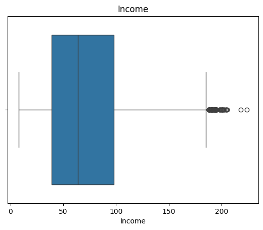

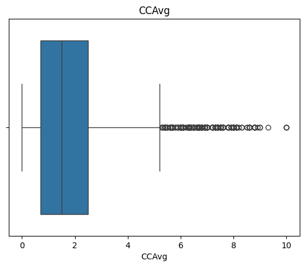

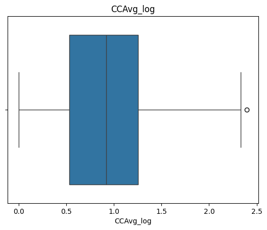

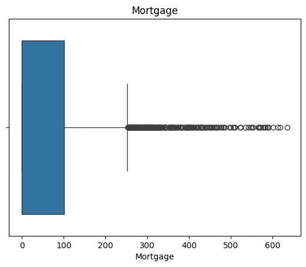

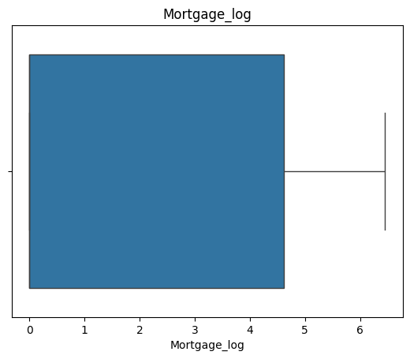

```python
for col in ['Income', 'CCAvg', 'CCAvg_log', 'Mortgage', 'Mortgage_log']:
    sns.boxplot(x=df[col])
    plt.title(f'{col}')
    plt.show()
```

Income still displays outliers and is right skewed, which makes sense because it wasn't transformed. There is a visible improvement when it comes to outliers treatment for CCAvg_log and Mortgage_log.

# Model Building

```python
df.drop(columns=['Mortgage','CCAvg', 'ZIPCode', 'Securities_Account'], inplace=True)

X = df.drop(columns=['Personal_Loan'])
y = df['Personal_Loan']
```

```python
df.head()
```

|  | Age | Experience | Income | Family | Education | Personal_Loan | CD_Account | Online | CreditCard | CCAvg_log | Mortgage_log |
| --- | --- | --- | --- | --- | --- | --- | --- | --- | --- | --- | --- |
| 0 | 25 | 1 | 49 | 4 | 1 | 0 | 0 | 0 | 0 | 0.955511 | 0.0 |
| 1 | 45 | 19 | 34 | 3 | 1 | 0 | 0 | 0 | 0 | 0.916291 | 0.0 |
| 2 | 39 | 15 | 11 | 1 | 1 | 0 | 0 | 0 | 0 | 0.693147 | 0.0 |
| 3 | 35 | 9 | 100 | 1 | 2 | 0 | 0 | 0 | 0 | 1.308333 | 0.0 |
| 4 | 35 | 8 | 45 | 4 | 2 | 0 | 0 | 0 | 1 | 0.693147 | 0.0 |

```python
X_train, X_test, y_train, y_test = train_test_split(
    X, y, test_size=0.3, random_state=42
)

decision_tree = DecisionTreeClassifier(random_state=42)
decision_tree.fit(X_train, y_train)

y_pred = decision_tree.predict(X_test)

print("Unpruned Tree Depth:", decision_tree.get_depth())
print("Unpruned Tree Leaves:", decision_tree.get_n_leaves())
print("Accuracy:", accuracy_score(y_test, y_pred))
print("Precision:", precision_score(y_test, y_pred))
print("Recall:", recall_score(y_test, y_pred))
print("F1 Score:", f1_score(y_test, y_pred))
```

```
Unpruned Tree Depth: 11
Unpruned Tree Leaves: 53
Accuracy: 0.9813333333333333
Precision: 0.9271523178807947
Recall: 0.89171974522293
F1 Score: 0.9090909090909091
```

# Model Performance Improvement

```python
#Pre-prune the decision tree
decision_tree_pruned = DecisionTreeClassifier(max_depth=7, min_samples_split=10, min_samples_leaf=5, random_state=42)

decision_tree_pruned.fit(X_train, y_train)
y_pred_pruned = decision_tree_pruned.predict(X_test)

decision_tree_pruned2 = DecisionTreeClassifier(max_depth=6, min_samples_split=20, min_samples_leaf=10, random_state=42)
decision_tree_pruned2.fit(X_train, y_train)
y_pred_pruned2 = decision_tree_pruned2.predict(X_test)

print("Unpruned Tree Depth:", decision_tree.get_depth())
print("Unpruned Tree Leaves:", decision_tree.get_n_leaves())
print()

print("Pruned Tree Depth:", decision_tree_pruned.get_depth())
print("Pruned Tree Leaves:", decision_tree_pruned.get_n_leaves())
print()

print("2nd Pruned Tree Depth:", decision_tree_pruned2.get_depth())
print("2nd Pruned Tree Leaves:", decision_tree_pruned2.get_n_leaves())
print()

print("Original decision tree")
print("Accuracy:", accuracy_score(y_test, y_pred))
print("Precision:", precision_score(y_test, y_pred))
print("Recall:", recall_score(y_test, y_pred))
print("F1 Score:", f1_score(y_test, y_pred))
print()

print("First pruned tree")
print("Accuracy:", accuracy_score(y_test, y_pred_pruned))
print("Precision:", precision_score(y_test, y_pred_pruned))
print("Recall:", recall_score(y_test, y_pred_pruned))
print("F1 Score:", f1_score(y_test, y_pred_pruned))
print()

print("Second pruned tree")
print("Accuracy:", accuracy_score(y_test, y_pred_pruned2))
print("Precision:", precision_score(y_test, y_pred_pruned2))
print("Recall:", recall_score(y_test, y_pred_pruned2))
print("F1 Score:", f1_score(y_test, y_pred_pruned2))
```

```
Unpruned Tree Depth: 11
Unpruned Tree Leaves: 53

Pruned Tree Depth: 7
Pruned Tree Leaves: 29

2nd Pruned Tree Depth: 6
2nd Pruned Tree Leaves: 19

Original decision tree
Accuracy: 0.9813333333333333
Precision: 0.9271523178807947
Recall: 0.89171974522293
F1 Score: 0.9090909090909091

First pruned tree
Accuracy: 0.9786666666666667
Precision: 0.9139072847682119
Recall: 0.8789808917197452
F1 Score: 0.8961038961038961

Second pruned tree
Accuracy: 0.9833333333333333
Precision: 0.9459459459459459
Recall: 0.89171974522293
F1 Score: 0.9180327868852459
```

**Conclusion:**

All three trees perform well. However, the second pruned tree performs the best - it's probably avoiding overfitting by reducing its complexity.

By pruning, not only did it reduce the number of leaves, the performance metrics also showed an improvement.

The second pruned model has the best performance metrics. It has a high accuracy, minimal risk of False Positives (precision) and will help target customers that are more likely to take on loans (recall).

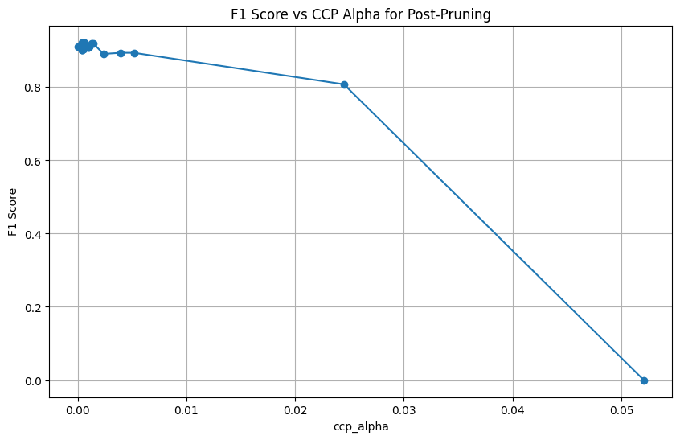

```
Pruned Tree Depth: 3
Pruned Tree Leaves: 5
```

```python
# post-pruning

clf_full = DecisionTreeClassifier(random_state=42)
clf_full.fit(X_train, y_train)

path = clf_full.cost_complexity_pruning_path(X_train, y_train)
ccp_alphas = path.ccp_alphas
impurities = path.impurities

clfs = []
for ccp_alpha in ccp_alphas:
    clf = DecisionTreeClassifier(random_state=42, ccp_alpha=ccp_alpha)
    clf.fit(X_train, y_train)
    clfs.append(clf)

f1_scores = [f1_score(y_test, clf.predict(X_test)) for clf in clfs]

plt.figure(figsize=(10, 6))
plt.plot(ccp_alphas, f1_scores, marker='o')
plt.xlabel("ccp_alpha")
plt.ylabel("F1 Score")
plt.title("F1 Score vs CCP Alpha for Post-Pruning")
plt.grid(True)
plt.show()

clf_postpruned = DecisionTreeClassifier(random_state=42, ccp_alpha=0.005)
clf_postpruned.fit(X_train, y_train)

print("Pruned Tree Depth:", clf_postpruned.get_depth())
print("Pruned Tree Leaves:", clf_postpruned.get_n_leaves())
```

**Conclusion:**

F1 score seems to be higher at the top left of the chart. Setting ccp_alpha to 0.005 is a good choice because it reduces the trees complexity and avoids overfitting.

```
Accuracy: 0.9793333333333333
Precision: 0.9701492537313433
Recall: 0.8280254777070064
F1 Score: 0.8934707903780069
```

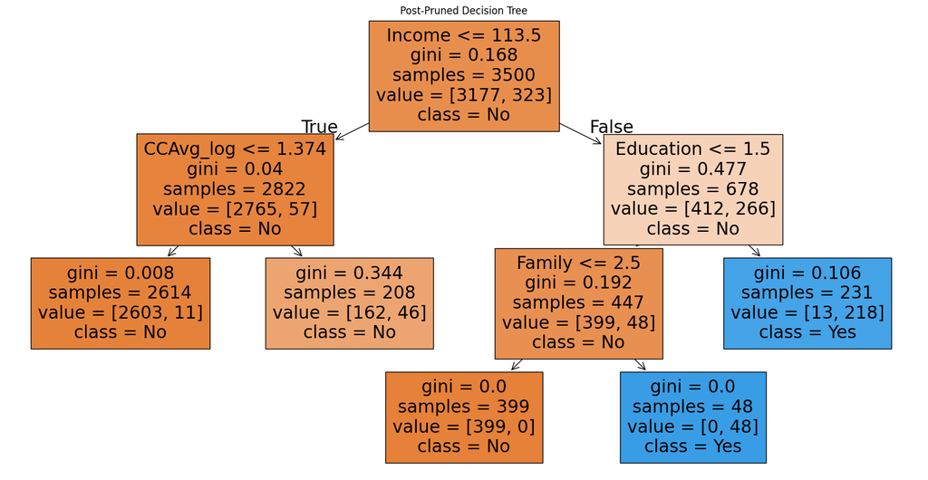

```python
y_pred = clf_postpruned.predict(X_test)

print("Accuracy:", accuracy_score(y_test, y_pred))
print("Precision:", precision_score(y_test, y_pred))
print("Recall:", recall_score(y_test, y_pred))
print("F1 Score:", f1_score(y_test, y_pred))

plt.figure(figsize=(20, 10))
plot_tree(clf_postpruned, filled=True, feature_names=X_train.columns, class_names=["No", "Yes"], max_depth=3)
plt.title("Post-Pruned Decision Tree")
plt.show()
```

**Conclusion:**

The post-pruned tree is simpler, with a depth of 3 and 5 leaves.

It has a high accuracy (97.9%) and precision (97%), resulting in few false positives.

Recall (83%) has worsen a bit though.

F1 (0.89) is a high number.

# Model Performance Comparison and Final Model Selection

**Conclusion:**

The Banks goal is to increase the number of customers as rapidly as possible, so the most important metrics are:

- Recall: Relates to True Positives; the Bank wants to identify as many potential loan takers as possible. A high recall is very important.
- Precision: Measures how many of the Predicted Positives are actually True Positives. The higher it is, the more efficient it is for the Marketing team.
- F1 Score: A balance between Precision and Recall.

Both the second pruned tree and the post-pruned tree display good metrics. However, the second pruned tree displays higher Recall, Accuracy and F1 Score. Because the Bank wants to target as many potential customers as possible and Recall helps with identifying them, Recall aligns well with this goal.

The second pruned tree is more complex but it is still simpler than the original tree.

```
        Feature  Importance
4     Education    0.415596
2        Income    0.335434
3        Family    0.174209
8     CCAvg_log    0.053958
5    CD_Account    0.016106
1    Experience    0.002851
6        Online    0.001584
0           Age    0.000262
7    CreditCard    0.000000
9  Mortgage_log    0.000000
```

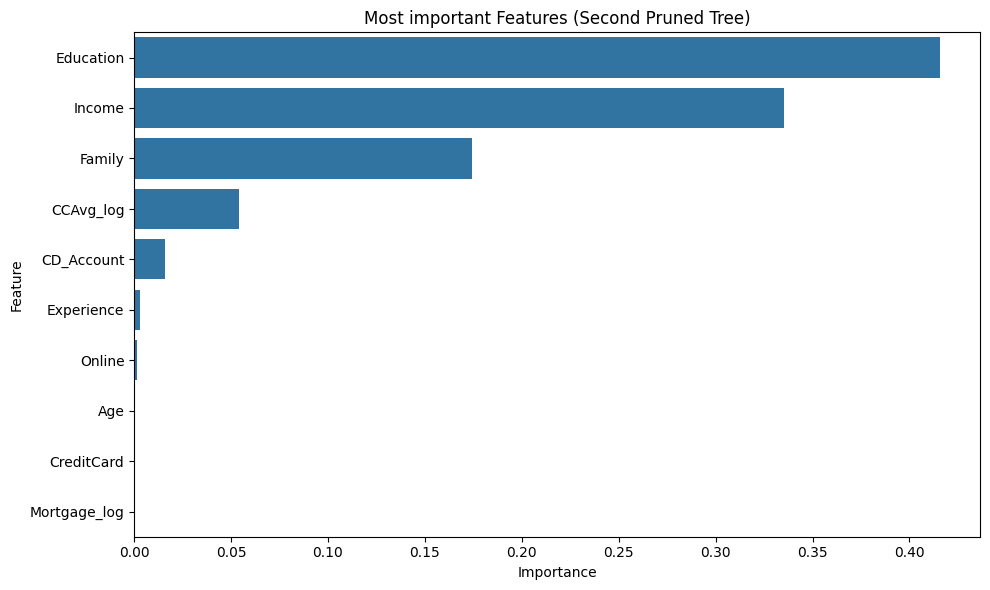

```python
importances = decision_tree_pruned2.feature_importances_

feature_importance_df = pd.DataFrame({
    'Feature': X_train.columns,
    'Importance': importances
}).sort_values(by='Importance', ascending=False)

print(feature_importance_df)

plt.figure(figsize=(10, 6))
sns.barplot(data=feature_importance_df.head(10), x='Importance', y='Feature')
plt.title("Most important Features (Second Pruned Tree)")
plt.tight_layout()
plt.show()
```

**Conclusion:** The most important features in the model are Education, Income and Family.

CCAvg_log and CD_Account follow.

# Actionable Insights and Business Recommendations

1. The Bank should focus on high-education and high-income customers as these two are the most important features in the model. Customers with 'Graduate' or 'Professional' levels are more likely to take on a personal loan.

Action: Identify high income individuals and/or individuals that have a higher-education level and target them in campaigns.

2. Bigger families are more likely to accept personal loans. As such, promoting deals that benefit families with children would be beneficial.

Action: Create products specifically for families commons expenses.

3. The higher the average credit card amount spent, the more likely the customer was to take on a personal loan.

Action: Identify the customers who spend more on credit cards and offer special deals if one takes on a personal loan.

4. ZIP Codes by themselves weren't a predictor in the model however, in the EDA it was demonstrated that some ZIP Codes have higher average incomes.

Action: The Marketing team could promote more campaigns on those areas as income is a strong predictor.

```python
%%shell
jupyter nbconvert --to html '/content/drive/MyDrive/Colab Notebooks/Personal Loan Campaign.ipynb'
```